# Homologação do Layout da especificação

(inicio)

# Atenção

A anonimização dos nomes e CPFs de credores pessoas físicas nas consultas de Despesa e Restos a Pagar (RP) referente elemento item de despesa 3102 - PRÊMIOS LOTÉRICOS deve permanecer conforme [demanda já disponibilizada em produção](https://github.com/transparencia-mg/especificacoes-portal-transparencia/blob/master/espec001_anonimizacao-cpf/anonimizacao-cpf-espec.md) e deverá sem aplicada antes dessa nova proposta de descaraterização.

## DADOS CONTINUAM ANONIMIZADOS - OK

Despesa - Dados verificados no ano de 2020.

[figure not shown]

# Especificação

(inicio)

Inicialmente, cabe destacar que todos os registros devem ser carregados novamente na base de dados do Portal da Transparência, de forma que todos os CPFs fiquem anonimizados.

**Não é possível verificar todo os anos, pois no ambiente de Homologação foi disponibilizado apenas os anos de 2019 e 2020. Nesse sentido, os demais anos serão verificados no ambiente de produção**.

A anonimização deve ser aplicada em:

- Gráficos e tabelas do nível favorecido (ex. Despesa ; RP; Diárias e Viagens);
- Formulários de detalhamento de documentos ex. Despesa ; RP; Diárias e Viagens);
- Tabela do nível nome do classificado (ex. Concursos realizados);
- Pesquisa avançada;
- Imprimir página;
- Exportar para csv;
- Exportar para pdf.

## Método de anonimização

A anonimização deve ser aplicada em **TODOS** os campos e filtros de **TODAS** as consultas que possuem informação de CPF.

O método de anonimização consiste em ocultar os três primeiros dígitos e dos dois dígitos verificadores dos CPFs.

**Exemplo:**  
Substituir o CPF pelo valor *** .456.526- **

Abaixo segue **EXEMPLOS** de algumas consultas de como a anonimização deve ocorrer:

## Concursos Realizados - OK

(inicio)

A anonimização deve ser aplicada no nível ‘Nome do Classificado’ em todos os filtros da consulta Concursos Realizados que possuem informação de CPF.

Ao acessar o nível ‘Nome do Classificado’, o Portal deverá exibir:

| Nome do Classificado | CPF |
| --- | --- |
| ADRIA DE LIMA SOUSA | *** .000.000- ** |

- *Obs: As demais colunas não sofrerão alterações*

## CONFERE

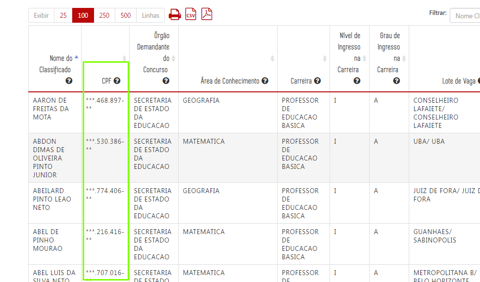

## Despesa, Restos a Pagar, Diárias e Viagens

(inicio)

A anonimização deve ser aplicada no nível ‘Favorecido’ de todos os filtros das consultas [Despesa]), [Diárias]), [Restos a Pagar]) que possuem informação de CPF.

Ao acessar o nível ‘Favorecido por nome’ ou ‘Favorecido por CNPJ/CPF’ o Portal deverá exibir:

### Consulta Despesa - OK

| Favorecido | CNPJ/CPF | Item de despesa | Valor Empenhado | Valor Liquidado | Valor Pago |
| --- | --- | --- | --- | --- | --- |
| MARCOS SAULO DE CARVALHO | *** .456.286- ** | DESPESAS MIUDAS DE PRONTO PAGAMENTO | 10.000,00 | 10.000,00 | 10.000,00 |

## CONFERE

Dados verificados em todos os filtros no ano de 2020.

[figure not shown]

- **Formulários de detalhamento de documentos**

Ao acessar os formulários de detalhamento, os seguintes campos devem ser anonimizados:

=> Campo *Razão Social do Credor, CNPJ/CPF e Descrição do Favorecido* do formulário de empenho da despesa:

## CONFERE

Dados verificados em todos os filtros no ano de 2020.

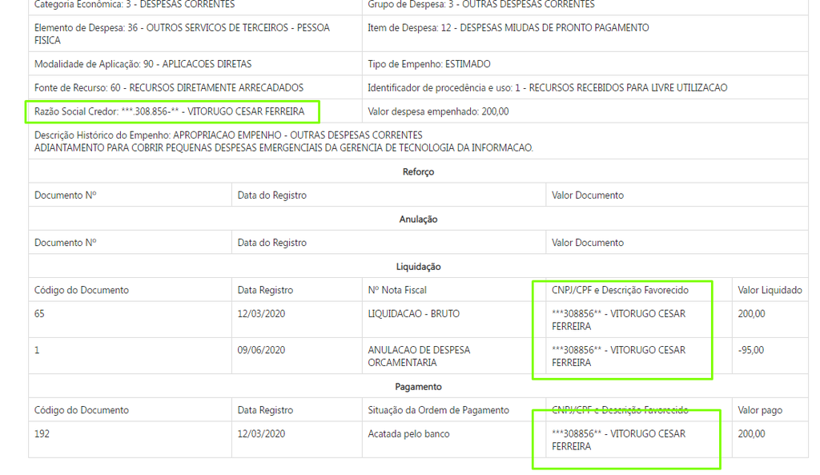

### Consulta Restos a Pagar - OK

| Favorecido | CNPJ/CPF | Número do empenho | Valor Inscrito Processado | Valor Inscrito não Processado | Valor Pago no ano | Valor a pagar |
| --- | --- | --- | --- | --- | --- | --- |
| MARCOS SAULO DE CARVALHO | *** .456.286- ** | 85 | 10.000,00 | 30.000,00 | 10.000,00 | 20.000,00 |

## CONFERE

Dados verificados em todos os filtros no ano de 2020.

[figure not shown]

- **Formulários de detalhamento de documentos**

Ao acessar os formulários de detalhamento, os seguintes campos devem ser anonimizados:

=>Campo *Razão Social do Credor, CNPJ/CPF e Descrição do Favorecido* do formulário de empenho da despesa:

## CONFERE

Dados verificados em todos os filtros no ano de 2020.

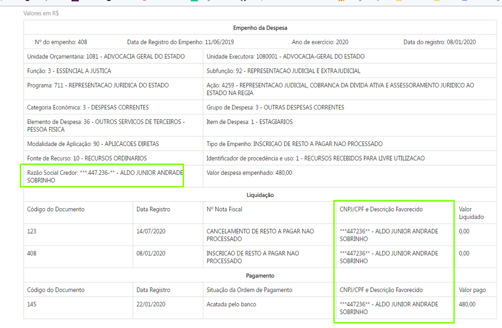

### Consulta Diárias - OK

| Favorecido | CNPJ/CPF | Valor Empenhado | Valor Liquidado | Valor Pago |
| --- | --- | --- | --- | --- |
| MARCOS SAULO DE CARVALHO | *** .456.286- ** | 10.000,00 | 10.000,00 | 10.000,00 |

## CONFERE

Dados verificados em todos os filtros no ano de 2020.

[figure not shown]

- **Formulários de detalhamento de documentos**

Ao acessar os formulários de detalhamento, os seguintes campos devem ser anonimizados:

=> Campo *Razão Social do Credor, CNPJ/CPF e Descrição do Favorecido* do formulário de empenho da despesa:

## CONFERE

Dados verificados em todos os filtros no ano de 2020.

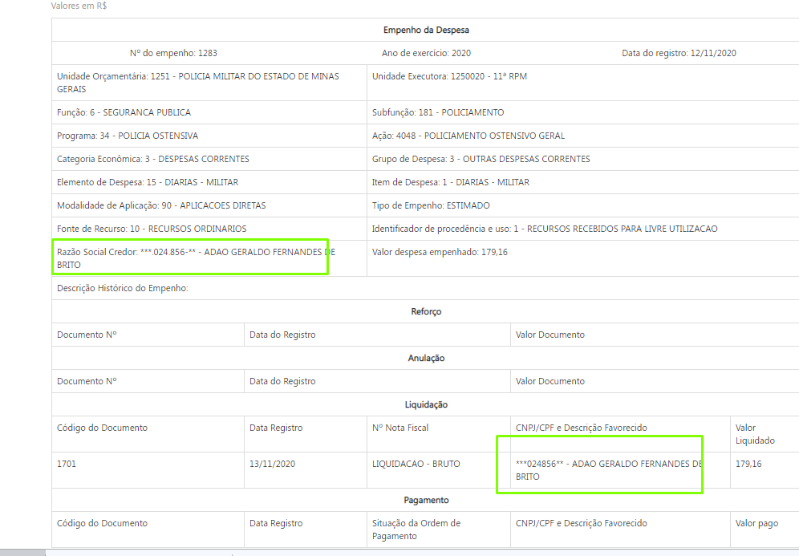

### Consulta Viagens - OK

| Favorecido | CNPJ/CPF | Cargo | Órgão | Quantidade de Viagens | Quantidade de Diárias | Valor Pago Diárias | Valor Pago Passagens | Valor Total |
| --- | --- | --- | --- | --- | --- | --- | --- | --- |
| MARCOS SAULO DE CARVALHO | *** .456.286- ** | Auditor Fiscal | Secretária de Estado da Fazenda | 1,00 | 1,00 | 0,00 | 0,00 | 0,00 |

## CONFERE

Dados verificados em todos os filtros no ano de 2020.

[figure not shown]

- **Formulários de detalhamento de documentos**

Ao acessar os formulários de detalhamento, os seguintes campos devem ser anonimizados:

## CONFERE

Dados verificados em todos os filtros no ano de 2020.

[figure not shown]

## Consulta Compras e Contratos - OK

(inicio)

A anonimização deve ser aplicada no nível ‘Contratado’ em todos os filtros da consulta Compras e Contratos que possuem informação de CPF.

Ao acessar o nível ‘Contratado’, o Portal deverá exibir:

Contratado| CNPJ/CPF | Valor de Referência | Valor Homologado | Economias

[output not shown]

## CONFERE

Dados verificados em todos os filtros no ano de 2020.

[figure not shown]

- **Formulários de detalhamento de documentos**

Ao acessar os formulários de detalhamento, os seguintes campos devem ser anonimizados:

## CONFERE

Dados verificados em todos os filtros no ano de 2020

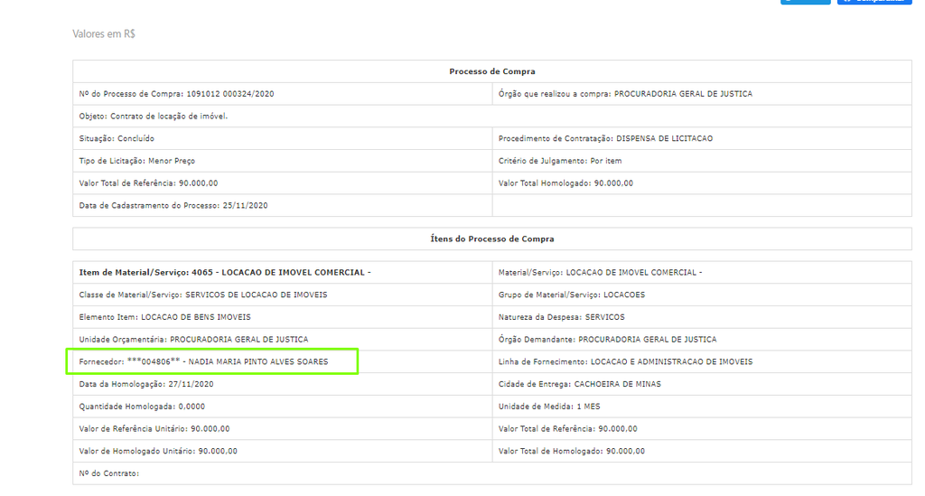

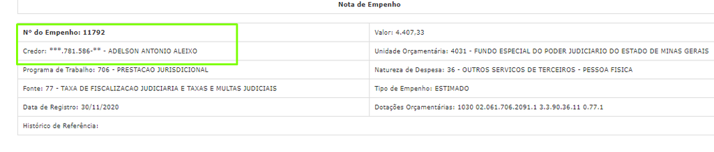

- **Formulário de detalhamento da consulta Contratos por órgão**

Ao acessar os formulários de detalhamento, os seguintes campos devem ser anonimizados:

## CONFERE

Dados verificados em todos os filtros no ano de 2020

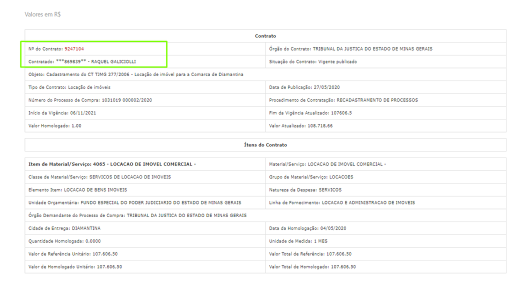

## Gestão da Frota - OK

(inicio)

A anonimização deve ser aplicada no nível ‘Proprietário’ em todos os filtros da consulta Gestão da Frota que possuem informação de CPF.

| Número do Patrimônio | Placa do Veículo | Marca/Modelo | Ano de Fabricação | Siatuação do Veículo | Tipo de bem | Proprietário | Finalidade do Veículo |
| --- | --- | --- | --- | --- | --- | --- | --- |
| — | — | — | — | — | – | *** .000.000- ** -SANDRO LUIS VILELA AVELAR |  |

## CONFERE

Dados verificados em todos os filtros no ano de 2020

[figure not shown]

- **Formulários de detalhamento de documentos**

Ao acessar os formulários de detalhamento, os seguintes campos devem ser anonimizados:

## CONFERE

Dados verificados em todos os filtros no ano de 2020

[figure not shown]

## Patrimônio - OK

(inicio)

A anonimização deve ser aplicada em todos os campos que tiver informação de CPFS e em todos os filtros da consulta [Patrimônio](http://www.transparencia.mg.gov.br/compras-e-patrimonio/patrimonio/patrimonio-terceiros-responsaveis/1/2/).

| CNPJ/CPF | Terceiro Responsável | Quantidade de Bens Ativos |
| --- | --- | --- |
| *** .000.000- ** | SANDRO LUIS VILELA AVELAR | - |

CORRIGIDO

[figure not shown]

*OBSERVAÇÕES GERAIS*

- As regras acima devem ser aplicadas inclusive no caso em que o nome e CPF sejam apresentados no mesmo campo (ex. formulários de detalhamento).

Confere nas consultas que possuem formulários de detalhamento

- No banco de dados do Portal da Transparência, as informações de CPF devem ser armazenadas sem anonimização, permitindo filtros que utilizem essas informações.
- A anonimização deve ocorrer em todas as pesquisas avançadas que apresentem informação de CPF.

## CONFERE

- Restos a pagar - 2020

[figure not shown]

* Despesa

[figure not shown]

- Frota

[figure not shown]

- Ao digitar o CPF de um favorecido na consulta ‘Favorecido por CPF / CNPJ’, o Portal deve exibir a consulta completa anonimizando os dados do favorecido.

## CONFERE

- Despesa - Consulta por favorecido CNPJ/CPF ano de 2020.

[figure not shown]

  —-
- Restos a pagar - Consulta por favorecido CNPJ/CPF ano de 2020.

[figure not shown]

- Os dados na migalha de pão (caminho da pesquisa) devem ser anonimizados quando exibir o número do CPF;

## CONFERE

- Despesa - Consulta por favorecido CNPJ/CPF ano de 2020.

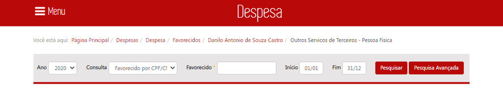

- Ao realizar uma anonimização, o Portal deve continuar a exibir as transações de forma separada.
- A anonimização deve ser aplicada na árvore de todas as consultas

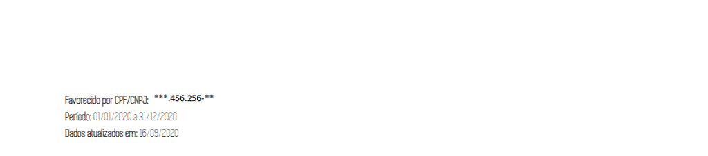

## Dúvida:

(inicio)

– Não é possível descaracterizar esses dados, pois são informações digitas pelo usuário. >“seguindo o mesmo princípio adotado na anonimização e considerando que a informação apresentada no site apenas representa a entrada de dados realizada pelo usuário, e não a recuperação de informações sensíveis, podemos considerar a não descaracterização dessa informação apresentada;”

[figure not shown]

- Quando o usuário clicar no número do processo de compra da consulta “[Compras - Programa de enfrentamento COVID -19](http://www.transparencia.mg.gov.br/covid-19/compras-contratos/contratoscovid-detalharcompra/145425)” deve-se aplicar as mesmas regras de anonimização adotada na Consulta de Compras e Contratos caso exista algum CPF.

Até o momento não existe contratação nessa consulta com pessoa física (CPF), assim não foi possível a conferência

Corrigido - O Portal apresenta erro ao não exibir todos os dados da coluna CPNJ/CPF. Ao realizar a pesquisa por nome do favorecido é exibido todos os favorecidos, porém os dados de CPNJ não estão sendo exibidos.

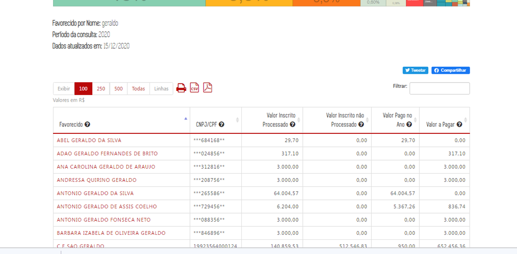

- O CPF administrativo do credor “Diárias e Favorecidos” não deverá ser descaracterizado, uma vez que não se refere a um credor pessoa física. Essa regra vale para todos os CPFs administrativos de todas as consultas

> " Os CPFs institucionais foram desconsiderados da regra, pois se tratam de um documento específico não diretamente associado a uma pessoa física;"
- DESPESA http://www.transparencia.mg.gov.br/despesa-estado/despesa/despesa-orgaos/2020/01-01-2020/31-12-2020/4015/1915/502/20/42

[figure not shown]

- Diárias http://homologa3.prodemge.gov.br/age7/estado-pessoal/diarias/despesadiarias-programas/2020/01-01-2020/31-12-2020/9807

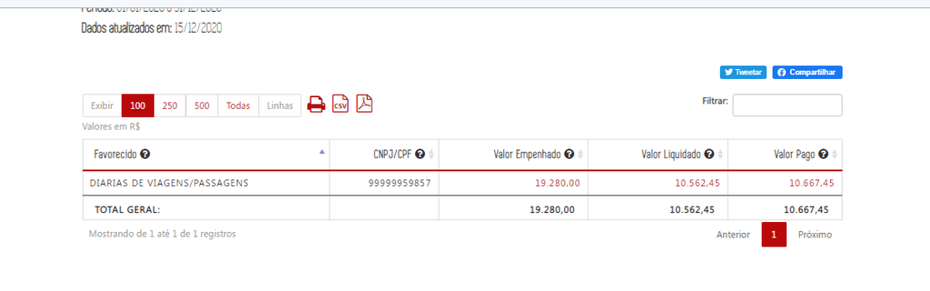